# act_report

## act_report

### Insights

- Most Liked and retweeted dog breeds based on favourite and retweet counts
- Distribution for dog breeds
- Checking the distribution for the tweet source
- Month with the highest frequency of tweets

```python
# Setting Figsize for better viewing
sns.set(rc={'figure.figsize':(14,8)})
```

### Most Liked and retweeted dog breeds based on favourite and retweet counts

```python
# Checking the dog breed preference based on likes
dog_breed_likes = df.groupby('dog_breed')['favorite_count'].sum().sort_values(ascending=False).head(6)
dog_breed_likes
```

```
dog_breed
Golden_retriever      1943782
Labrador_retriever    1265355
Pembroke              1038797
Chihuahua              743689
Samoyed                583906
French_bulldog         570921
Name: favorite_count, dtype: int64
```

```python
# Checking The dog breed preference based on retweet count
dog_breed_retweet = df.groupby('dog_breed')['retweet_count'].sum().sort_values(ascending=False).head(6)
dog_breed_retweet
```

```
dog_breed
Golden_retriever      586657
Labrador_retriever    405404
Pembroke              291771
Chihuahua             250722
Samoyed               203446
French_bulldog        156230
Name: retweet_count, dtype: int64
```

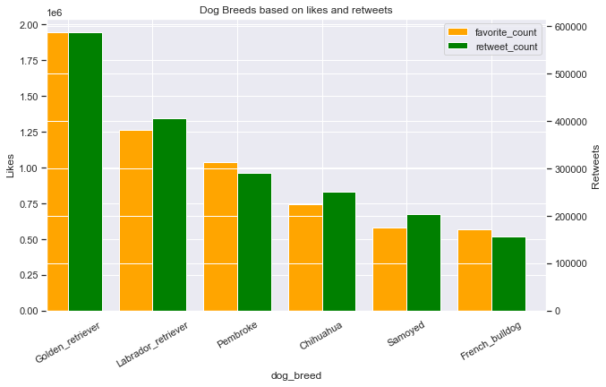

```python
fig, ax1 = plt.subplots()
ax2 = ax1.twinx()


dog_breed_likes.plot(figsize = (10,6), kind='bar', color='orange', ax=ax1, width=0.4, position=1,
             title='Dog Breeds based on likes and retweets')
dog_breed_retweet.plot(figsize = (10,6), kind='bar', color='green', ax=ax2, width=0.4, position=0)

ax1.set_ylabel('Likes')
ax2.set_ylabel('Retweets')
ax1.set_xticklabels(dog_breed_likes.index, rotation=30)

h1, l1 = ax1.get_legend_handles_labels()
h2, l2 = ax2.get_legend_handles_labels()

plt.legend(h1+h2, l1+l2, loc=1)
#save pic
plt.savefig('popular_dogs.png', dpi=100)

plt.show();
```

The bar chart displays Dog breeds based on favourite and retweet counts. The x-axis represents dog breed, and the y-axis displays likes. The bars represent number of likesa dog breed received by users. The bar chart shows that the Golden Retriever is the most liked breed followed by the Labrador Retriever. Overall, the bar chart suggests that Golden Retriever are the most loved dog breed in the dog world.

### Distribution for dog breeds

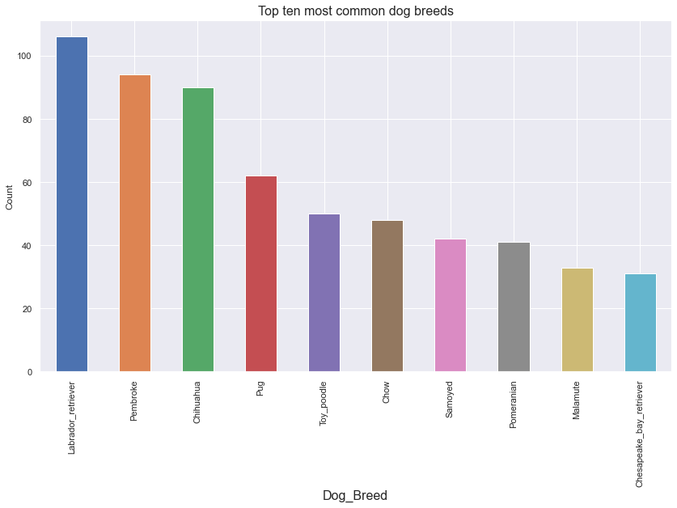

```python
df.dog_breed.value_counts().head(11)[1:].plot(kind = 'bar')
plt.xlabel('Dog_Breed', fontsize=16)
plt.title('Top ten most common dog breeds', fontsize=16)
plt.ylabel('Count');
```

### Checking the distribution for the tweet source

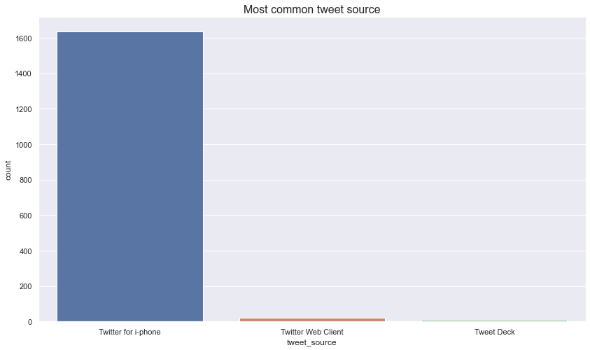

```python
# Checking the month with the highest frequency of tweets
ax1 = sns.countplot(x='tweet_source', data=df)
plt.title("Most common tweet source", fontsize=16);
```

The bar chart displays distribution of mobile devices/sources used by users. The x-axis represents sources, and the y-axis displays count. The bar chart shows that most tweet post comes from the Iphone mobile devices followed by Twitter web client. Overall, the bar chart suggests it is easier to post content using our mobile devices than anyother device.

### Month with the highest frequency of tweets

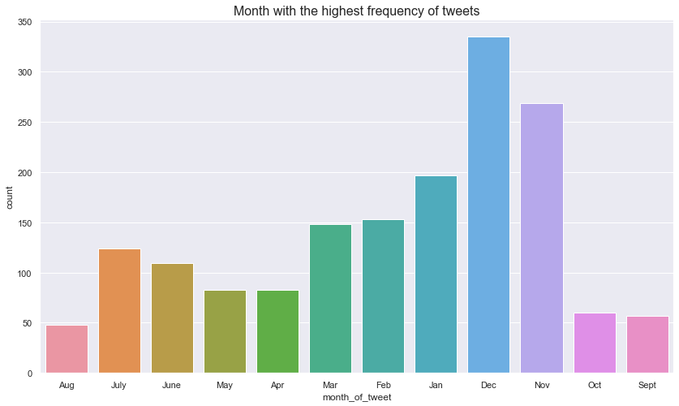

```python
# Checking the month with the highest frequency of tweets
ax1 = sns.countplot(x='month_of_tweet', data=df)
plt.title("Month with the highest frequency of tweets", fontsize= 16);
```

The bar chart displays the frequency of tweets per month. The x-axis represents month, and the y-axis displays count. The bars represent number of post by users. The bar chart shows that the month of December is the month with highest post followed by the November. Overall, the bar chart shows that the month of December is the month with the highest post, it might be due to the fact that its a festive period.